# 201.5. DiaSource table

For the Rubin Science Platform at data.lsst.cloud.  
Data Release: [Data Preview 1](https://dp1.lsst.io/)  
Container Size: large  
LSST Science Pipelines version: r29.2.0  
Last verified to run: 2025-09-02  
Repository: github.com/lsst/tutorial-notebooks

**Learning objective:** To understand the contents of the `DiaSource` table and how to access it.

**LSST data products:** `DiaSource`

**Packages:** `lsst.rsp`, `lsst.daf.butler`

**Credit:** Originally developed by the Rubin Community Science team with feedback from Eric Bellm, Federica Bianco, and Tatiana Cuellar. Please consider acknowledging them if this notebook is used for the preparation of journal articles, software releases, or other notebooks.

**Get Support:** Everyone is encouraged to ask questions or raise issues in the [Support Category](https://community.lsst.org/c/support) of the Rubin Community Forum. Rubin staff will respond to all questions posted there.

## 1. Introduction

The `DiaSource` table contains measurements for sources--fading or brightening--detected in an individual `difference_image` with signal-to-noise ratio $\geq5$.

- TAP table name: `dp1.DiaSource`
- butler table name: `dia_source`
- columns: 87
- rows: 3,086,404

**Related tutorials:** The TAP and butler data access services are demonstrated in the 100-level "How to" tutorials. There are 200-level tutorials on `difference_images` and `DiaObjects`.

### 1.1. Import packages

Import standard python packages `re`, `numpy`, `matplotlib` and `astropy`.

From the `lsst` package, import modules for the TAP service, the butler, and plotting.

```python
import re
import numpy as np
import matplotlib.pyplot as plt
import matplotlib.patches as patches
from lsst.rsp import get_tap_service
from lsst.daf.butler import Butler
from lsst.utils.plotting import (get_multiband_plot_colors,
                                 get_multiband_plot_symbols)
```

### 1.2. Define parameters and functions

Create an instance of the TAP service, and assert that it exists.

```python
service = get_tap_service("tap")
assert service is not None
```

Create an instance of the Rubin data butler, and assert that it exists.

```python
butler = Butler('dp1', collections="LSSTComCam/DP1")
assert butler is not None
```

Define the colors and symbols to represent the LSST filters in plots.

```python
filter_names = ['u', 'g', 'r', 'i', 'z', 'y']
filter_colors = get_multiband_plot_colors()
filter_symbols = get_multiband_plot_symbols()
```

## 2. Schema (columns)

To browse the table schema visit the [Rubin schema browser](https://sdm-schemas.lsst.io/), or use the TAP service via the Portal Aspect or as demonstrated in Section 2.1.

### 2.1. Retrieve table schema

To retrieve the table schema, define a query for the schema columns of the `DiaSource` table and run the query job.

```python
query = "SELECT column_name, datatype, description, unit " \
        "FROM tap_schema.columns " \
        "WHERE table_name = 'dp1.DiaSource'"
job = service.submit_job(query)
job.run()
job.wait(phases=['COMPLETED', 'ERROR'])
print('Job phase is', job.phase)
if job.phase == 'ERROR':
    job.raise_if_error()
assert job.phase == 'COMPLETED'
```

```
Job phase is COMPLETED
```

Retrieve the query results and display them as an `astropy` table with the `to_table()` attribute.

```python
results = job.fetch_result().to_table()
results
```

*Table length=87*

| column_name str64 | datatype str64 | description str512 | unit str64 |
| --- | --- | --- | --- |
| apFlux | float | Flux in a 12 pixel radius aperture on the difference image. | nJy |
| apFlux_flag | boolean | General aperture flux algorithm failure flag; set if anything went wrong when measuring aperture fluxes. Another apFlux flag field should also be set to provide more information. |  |
| apFlux_flag_apertureTruncated | boolean | Aperture did not fit within measurement image. |  |
| apFluxErr | float | Estimated uncertainty of apFlux. | nJy |
| band | char | Band used to take this observation. |  |
| bboxSize | long | Bounding box of diaSource footprint. |  |
| centroid_flag | boolean | General centroid algorithm failure flag; set if anything went wrong when fitting the centroid. Another centroid flag field should also be set to provide more information. |  |
| coord_dec | double | Fiducial ICRS Declination of centroid used for database indexing. | deg |
| coord_ra | double | Fiducial ICRS Right Ascension of centroid used for database indexing. | deg |
| dec | double | Position in declination. | deg |
| decErr | float | Error in declination. | deg |
| detector | long | Id of the detector where this diaSource was measured. Datatype short instead of byte because of DB concerns about unsigned bytes. |  |
| diaObjectId | long | Id of the DiaObject that this DiaSource was associated with. |  |
| diaSourceId | long | Unique identifier of this DiaSource. |  |
| dipoleAngle | double | Dipole orientation | deg |
| dipoleChi2 | double | Chi2 per degree of freedom of dipole fit. |  |
| dipoleFitAttempted | boolean | Attempted to fit a dipole model to this source. |  |
| dipoleFluxDiff | double | Raw flux counts, positive lobe. | nJy |
| dipoleFluxDiffErr | double | Raw flux uncertainty counts, positive lobe. | nJy |
| ... | ... | ... | ... |
| scienceFluxErr | float | Forced PSF flux uncertainty measured on the direct image. | nJy |
| shape_flag | boolean | General source shape algorithm failure flag; set if anything went wrong when measuring the shape. Another shape flag field should also be set to provide more information. |  |
| shape_flag_no_pixels | boolean | No pixels to measure shape. |  |
| shape_flag_not_contained | boolean | Center not contained in footprint bounding box. |  |
| shape_flag_parent_source | boolean | This source is a parent source; we should only be measuring on deblended children in difference imaging. |  |
| snr | double | Ratio of apFlux/apFluxErr |  |
| ssObjectId | long | Id of the ssObject this source was associated with, if any. If not, it is set to 0 |  |
| time_processed | char | Time when the image was processed and this DiaSource record was generated. |  |
| trail_flag_edge | boolean | This flag is set if a trailed source contains edge pixels. |  |
| trailAngle | double | Angle measured from +x-axis. |  |
| trailDec | double | Trail centroid declination. | deg |
| trailFlux | float | Trailed source flux. | nJy |
| trailLength | double | Trail length. | pixel |
| trailRa | double | Trail centroid right ascension. | deg |
| visit | long | Id of the visit where this diaSource was measured. |  |
| x | double | Unweighted first moment centroid, overall centroid | pixel |
| xErr | float | 1-sigma uncertainty on x position | pixel |
| y | double | Unweighted first moment centroid, overall centroid | pixel |
| yErr | float | 1-sigma uncertainty on y position | pixel |

The table displayed above has been truncated.

Option to print every column name as a list.

```python
# for col in results['column_name']:
#     print(col)
```

Option to use the regular expressions package `re` to search for column names that contain the string `temp`.

```python
# temp = 'Err'
# temp = 'Flux'
# temp = 'psf'
# for col in results['column_name']:
#     if re.search(temp, col):
#         print(col)
```

Delete the job, but not the `results`.

```python
del query
job.delete()
```

### 2.2. Key columns

Of the 87 columns of the `DiaSource` table, a $\sim$dozen are the most commonly used.

#### 2.2.1. DiaSource Id

The long integer that uniquely identifies each row of the `DiaSource` table.

- `diaSourceId`

#### 2.2.2. DiaObject Id

The long integer that identifies the Id of the DiaObject that this `DiaSource` is associated with.

- `diaObjectId`

#### 2.2.3. SSObject Id

The long integer that identifies the Id of the ssObject that this `DiaSource` is associated with, if any. If no ssObject is associated with the DiaSource, then this value is set to 0.

- `ssObjectId`

#### 2.2.4. Filter

The filter band used for the observation of the `DiaSource`.

- `band`

#### 2.2.5. Visit Id and detector

The `visit` is a long integer that uniquely identifies the visit the `DiaSources` were detected. The `detector` is which of the 9 LSSTComCam detectors the `DiaSources` were detected on. Together, the `visit` and `detector` correspond to a processed `visit_image`.

- `visit`
- `detector`

#### 2.2.6. Time of observation

Effective mid-exposure time for visit where the `DiaSource` was detected, expressed as Modified Julian Date, International Atomic Time.

- `midpointMjdTai`

#### 2.2.7. Coordinates

The sky coordinates in decimal degrees for each `DiaSource`:

- `ra`, `raErr`
- `dec`, `decErr`

#### 2.2.8. Flux

Fluxes are provided in nanoJanskys, which is preffered for difference-image photometry over magnitudes since negative flux measurements would be omitted when converting to magnituides.

**PSF fluxes**

A forced fit of the Point Spread Function (PSF) at the DiaSource's coordinates in each difference image. PSF fluxes are best to use for point-like sources.

- `psfFlux`, `psfFluxErr`

Note that in the `DiaSource` table, the `psfFlux` column contains fluxes measured on the difference image. In other tables `psfFlux` is a flux on the direct (science) image.

**Other measurements**

- `apFlux`: fluxes in a 12 pixel radius aperture on the `difference_image`.
- `scienceFlux`: Forced PSF flux measured on the direct `visit_image`.

#### 2.2.9. Flags

**Pixel flags**

A variety of flags indicating whether pixels that are saturated, or affected by cosmic rays, contributed to the DiaSource's measurements.

- `pixelFlags_*`

**Measurement flags**

The flux (and shape) measurements mentioned above have associated flag columns suffixed with `_flag`.

**isDipole flag**

- `isDipole`

A boolean flag indicating whether or not the `diaSource` is classified as a dipole, a likely image-differencing artifact that appears as offset positive and negative lobes. Setting this to `False` will filter out poorly subtracted stars.

#### 2.2.10. Reliability score

- `reliability`

The purpose of the `reliability` score in the `DiaSource` table is to provide a threshold measure to improve the purity of DIA detections. This score is computed using information from the source and image characterization, as well as the information on the Telescope and Camera system. However, given that the reliability score model was trained on a relatively small and limited dataset, some caution is warranted in interpreting the `reliability` score in DP1, in particular for variable stars. Significant improvements are expected on future releases with LSSTCam data.

### 2.3. Descriptions and units

For a subset of the key columns show the table of their descriptions and units.

```python
col_list = set(['diaSourceId', 'diaObjectId', 'ssObjectId', 'band', 'visit',
                'midpointMjdTai', 'ra', 'dec', 'psfFlux', 'psfFluxErr', 'isDipole'])
tx = [i for i, item in enumerate(results['column_name']) if item in col_list]
results[tx]
```

*Table length=11*

| column_name str64 | datatype str64 | description str512 | unit str64 |
| --- | --- | --- | --- |
| band | char | Band used to take this observation. |  |
| dec | double | Position in declination. | deg |
| diaObjectId | long | Id of the DiaObject that this DiaSource was associated with. |  |
| diaSourceId | long | Unique identifier of this DiaSource. |  |
| isDipole | boolean | Source well fit by a dipole. |  |
| midpointMjdTai | double | Effective mid-exposure time for this diaSource, expressed as Modified Julian Date, International Atomic Time. |  |
| psfFlux | float | Flux derived from linear least-squares fit of PSF model. | nJy |
| psfFluxErr | float | Flux uncertainty derived from linear least-squares fit of PSF model. | nJy |
| ra | double | Position in right ascension. | deg |
| ssObjectId | long | Id of the ssObject this source was associated with, if any. If not, it is set to 0 |  |
| visit | long | Id of the visit where this diaSource was measured. |  |

Clean up.

```python
del col_list, tx, results
```

## 3. Data access

The `DiaSource` table is available via the TAP service and the butler.

**Recommended access method:** TAP.

### 3.1. Advisory: avoid full-table queries

**Avoid full-table queries. Always include a constraint on the coordinates or `visit`.**

The `DiaSource` table is a large set of all the measurements made in all the difference images of all detected sources.

The DP1 data release `DiaSource` table is relatively small, however, skipping spatial constraints is not a good habit to form, because **future data release `DiaSource` tables will contain trillions of rows**.

### 3.2. Advisory: not recommended for light curves

**The `ForcedSourceOnDiaObject` table is recommended for light curves.**

The `DiaSource` table contains measurements of difference-image sources with $\geq5\sigma$ detections, which mean lower-level variable/transient behavior will not be captured.

The `ForcedSourceOnDiaObject` table, which contains forced PSF photometry for *all* difference images as well as non-difference (i.e. `visit`) images, is recommended for variable and transient object light curves.

### 3.3. TAP (Table Access Protocol)

The `DiaSource` table is stored in Qserv and accessible via the TAP services using ADQL queries.

**Include spatial constraints:** Qserv stores catalog data sharded by coordinate (RA, Dec), so ADQL query statements that include constraints by coordinate do not requre a whole-catalog search and are typically faster (and can be much faster) than ADQL query statements which only include constraints for other columns. Use either an ADQL cone or polygon search for faster queries (do not use `WHERE ... BETWEEN` statements to set boundaries on RA and Dec).

#### 3.3.1. Demo query

Define a query to return the "key columns" from Section 2.3.

Impose **spatial constraints**: search within a 2 arcsecond radius of a known transient in the Extended Chandra Deep Field South (ECDFS) field, RA, Dec = $53.125, -27.740$.

```python
ra = 53.124768
dec = -27.739815
```

```python
query = """SELECT diaSourceId, diaObjectId, ssObjectId, band, visit,
        midpointMjdTai, ra, dec, psfFlux, psfFluxErr, isDipole
        FROM dp1.DiaSource
        WHERE CONTAINS(POINT('ICRS', ra, dec),
        CIRCLE('ICRS', {}, {}, 0.00056)) = 1
        ORDER BY diaSourceId ASC""".format(ra, dec)
print(query)
job = service.submit_job(query)
job.run()
job.wait(phases=['COMPLETED', 'ERROR'])
print('Job phase is', job.phase)
if job.phase == 'ERROR':
    job.raise_if_error()
assert job.phase == 'COMPLETED'
```

```
SELECT diaSourceId, diaObjectId, ssObjectId, band, visit,
        midpointMjdTai, ra, dec, psfFlux, psfFluxErr, isDipole
        FROM dp1.DiaSource
        WHERE CONTAINS(POINT('ICRS', ra, dec),
        CIRCLE('ICRS', 53.124768, -27.739815, 0.00056)) = 1
        ORDER BY diaSourceId ASC
```

```
Job phase is COMPLETED
```

Fetch the results as an `astropy` table.

```python
results = job.fetch_result().to_table()
print(len(results))
```

```
268
```

Option to display the table.

```python
# results
```

Filter out the DiaSources that exhibit a dipole

```python
tx = ~results['isDipole']
print(len(results[tx]))
```

```
256
```

Plot the RA and Dec offsets of every DiaSource that does not exhibit a dipole from the search coordinates, in arcseconds.

```python
results['ra_offset_arcsec'] = (results['ra'] - ra) * 3600.0
results['dec_offset_arcsec'] = (results['dec'] - dec) * 3600.0
```

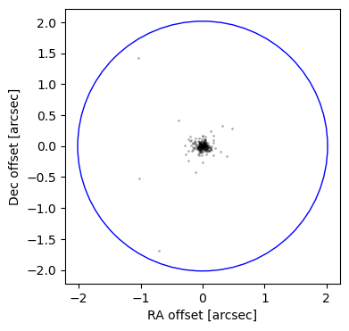

```python
fig, ax = plt.subplots(figsize=(4, 4))
circle = patches.Circle((0, 0), radius=0.00056*3600.0,
                        facecolor='None', edgecolor='blue')
ax.add_patch(circle)
ax.plot(results[tx]['ra_offset_arcsec'],
        results[tx]['dec_offset_arcsec'],
        'o', ms=2, mew=0, alpha=0.3, color='black')
ax.set_aspect(1)
plt.xlabel('RA offset [arcsec]')
plt.ylabel('Dec offset [arcsec]')
plt.tight_layout()
plt.show()
```

> **Figure 1:** The offset in RA and Dec, in arcseconds, of every source from the search coordinates. A 2" radius circule marks the search region.

Clean up.

```python
job.delete()
del query, results, tx
```

#### 3.3.2. Joinable tables

**DiaObject Table**

The `DiaSource` table can be joined to the `DiaObject` table on the column containing the unique `diaObjectId`.

The `DiaObject` table contains statistical information from `DiaSource` properties associated with the DiaObject.

Query the same coordinates as the previous subsection (with a smaller 1-arcsecond search radius and `band` = *r*) and add a table join to the `DiaObject` table to retrive the `r_psfFluxMax`, the maximum *r*-band difference-image PSF flux, and `nDiaSources`, the number of diaSources associated with the DiaObject.

```python
query = """SELECT dias.diaSourceId, dias.psfFlux, diao.r_psfFluxMax, diao.nDiaSources
        FROM dp1.DiaSource AS dias
        JOIN dp1.DiaObject AS diao ON dias.diaObjectId = diao.diaObjectId
        WHERE CONTAINS(POINT('ICRS', dias.ra, dias.dec),
        CIRCLE('ICRS', {}, {}, 0.00028)) = 1
        AND dias.band = 'r'
        ORDER BY dias.diaSourceId ASC""".format(ra, dec)
print(query)
job = service.submit_job(query)
job.run()
job.wait(phases=['COMPLETED', 'ERROR'])
print('Job phase is', job.phase)
if job.phase == 'ERROR':
    job.raise_if_error()
assert job.phase == 'COMPLETED'
```

```
SELECT dias.diaSourceId, dias.psfFlux, diao.r_psfFluxMax, diao.nDiaSources
        FROM dp1.DiaSource AS dias
        JOIN dp1.DiaObject AS diao ON dias.diaObjectId = diao.diaObjectId
        WHERE CONTAINS(POINT('ICRS', dias.ra, dias.dec),
        CIRCLE('ICRS', 53.124768, -27.739815, 0.00028)) = 1
        AND dias.band = 'r'
        ORDER BY dias.diaSourceId ASC
```

```
Job phase is COMPLETED
```

Fetch the results as an `astropy` table.

```python
results = job.fetch_result().to_table()
```

Show the maximum *r*-band PSF flux and the number of diaSources associated with the DiaObject which was retrieved from the `DiaObject` table.

```python
print(np.unique(results['r_psfFluxMax'][0]))
print(np.unique(results['nDiaSources'][0]))
```

```
[5481.84472656]
[253]
```

Show that this is consistent with the maximum `psfFlux` measurement from the `diaSources`.

```python
np.max(results['psfFlux'])
```

```
np.float32(5481.84)
```

```python
del ra, dec
```

**SSObject Table**

The `DiaSource` table can also be joined to the `SSObject` table on the column containing the unique `ssObjectId`.

Query a 1-degree cone search of the center of the Extended Chandra Deep Field South (ECDFS) field (RA, Dec = $53.13, -28.10$) and add a table join to the `SSObject` table to identify ssObjects.

```python
ra_cen = 53.13
dec_cen = -28.10
```

```python
query = """SELECT dias.diaSourceId, dias.ra, dias.dec, sso.ssObjectId
        FROM dp1.DiaSource AS dias
        JOIN dp1.SSObject AS sso ON dias.ssObjectId = sso.ssObjectId
        WHERE CONTAINS(POINT('ICRS', dias.ra, dias.dec),
        CIRCLE('ICRS', {}, {}, 0.5)) = 1
        ORDER BY dias.diaSourceId ASC""".format(ra_cen, dec_cen)
print(query)
job = service.submit_job(query)
job.run()
job.wait(phases=['COMPLETED', 'ERROR'])
print('Job phase is', job.phase)
if job.phase == 'ERROR':
    job.raise_if_error()
assert job.phase == 'COMPLETED'
```

```
SELECT dias.diaSourceId, dias.ra, dias.dec, sso.ssObjectId
        FROM dp1.DiaSource AS dias
        JOIN dp1.SSObject AS sso ON dias.ssObjectId = sso.ssObjectId
        WHERE CONTAINS(POINT('ICRS', dias.ra, dias.dec),
        CIRCLE('ICRS', 53.13, -28.1, 0.5)) = 1
        ORDER BY dias.diaSourceId ASC
```

```
Job phase is COMPLETED
```

Fetch the results as an `astropy` table.

```python
results = job.fetch_result().to_table()
```

Show the SSObjects associated with `diaSources` within the 1-degree cone search.

```python
np.unique(results['ssObjectId'])
```

<MaskedColumn name='ssObjectId' dtype='int64' length=9>

| 21163620217073748 |
| --- |
| 21163637482928473 |
| 21163645768577093 |
| 21164728252512342 |
| 21164741002015298 |
| 21164745447978322 |
| 23133931615301680 |
| 23133931615301681 |
| 23133931615301682 |

Plot the RA and Dec offsets of every `diaSource` from the search coordinates (in degrees) for all `diaSources` in the search region that are associated with a SSObject.

```python
results['ra_offset_deg'] = (results['ra'] - ra_cen)
results['dec_offset_deg'] = (results['dec'] - dec_cen)
```

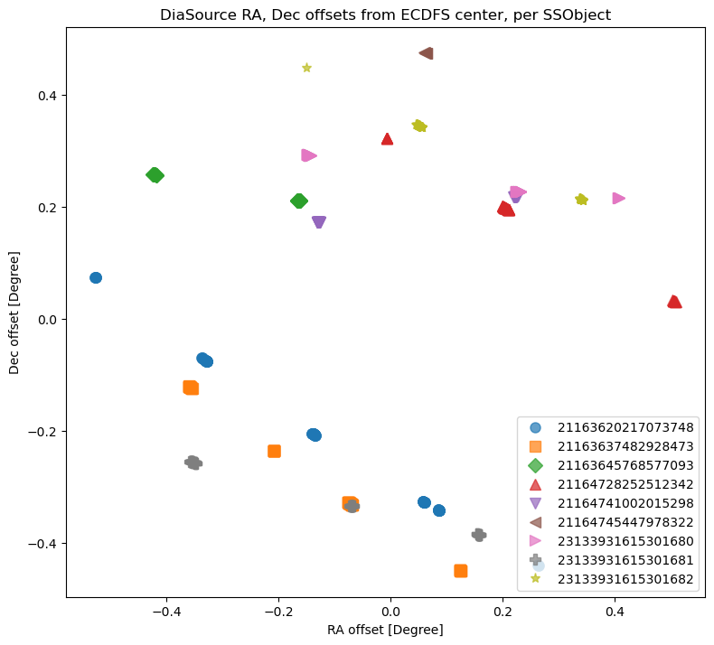

```python
marker_styles = ['o', 's', 'D', '^', 'v', '<', '>', 'P', '*', 'X']

fig, ax = plt.subplots(figsize=(8, 8))
for i, ssobj in enumerate(np.unique(results['ssObjectId'])):
    fx = np.where(results['ssObjectId'] == ssobj)[0]
    ax.plot(results['ra_offset_deg'][fx],
            results['dec_offset_deg'][fx],
            marker_styles[i], ms=8, alpha=0.7, label=ssobj)
ax.set_aspect(1)
plt.xlabel('RA offset [Degree]')
plt.ylabel('Dec offset [Degree]')
plt.legend(loc='lower right')
plt.title('DiaSource RA, Dec offsets from ECDFS center, per SSObject')
plt.tight_layout()
plt.show()
```

> **Figure 2:** The RA and Dec offsets of `diaSources` associated with 9 different SSObjects, when those moving objects were within 1 degree of the ECDFS field center.

Clean up.

```python
job.delete()
del query, results
```

### 3.4. Butler

TAP is the recommended way to access the `diaSource` table, but the butler is a convenient way to retrive all `diaSources` detected in a given tract.

Show that the dimension for the `dia_source` table is just the skymap's tract, and that it is required.

```python
butler.get_dataset_type('dia_source')
```

```
DatasetType('dia_source', {skymap, tract}, ArrowAstropy)
```

```python
butler.get_dataset_type('dia_source').dimensions.required
```

```
{skymap, tract}
```

#### 3.4.1. Demo query

Retrieve the dataset references (`refs`) for `dia_source` tables for tracts that overlap the coordinates near the center of the ECDFS field. There will be only 1.

```python
refs = butler.query_datasets("dia_source",
                             where="tract.region OVERLAPS POINT(:ra, :dec)",
                             bind={"ra": ra_cen, "dec": dec_cen},
                             order_by='tract')
print(len(refs))
```

```
1
```

Define a subset of columns to retrieve from the butler, and retrieve the table data.

```python
col_list = set(['diaSourceId', 'band', 'midpointMjdTai',
                'ra', 'dec', 'psfFlux', 'psfFluxErr'])

results = butler.get(refs[0],
                     parameters={'columns': col_list})
print(len(results))
```

```
401814
```

Subset the results to r-band fluxes between 20 and 25 mag.

```python
tx = np.where((results['psfFlux'] > 360.0)
              & (results['psfFlux'] <= 36000.0)
              & (results['band'] == 'r'))[0]
print(len(tx))
```

```
57952
```

As an example, plot the sky coordinates of `DiaSources`, and their flux vs. uncertainty.

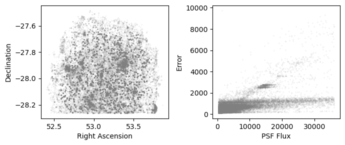

```python
fig, (ax1, ax2) = plt.subplots(1, 2, figsize=(7, 3))
ax1.plot(results['ra'][tx], results['dec'][tx],
         'o', ms=2, mew=0, alpha=0.1, color='grey')
ax1.set_xlabel('Right Ascension')
ax1.set_ylabel('Declination')
ax2.plot(results['psfFlux'][tx], results['psfFluxErr'][tx],
         'o', ms=2, mew=0, alpha=0.1, color='grey')
ax2.set_xlabel('PSF Flux')
ax2.set_ylabel('Error')
plt.tight_layout()
plt.show()
```

> **Figure 3**: At left, the RA vs. Dec of `DiaSources` as grey overlapping points, appearing darker for the locations of `DiaObjects` with many detections. At right, the PSF flux in the difference image, vs. its uncertainty.